# Risk Factor Analysis

## Outcome Variable

**Outcome Variable:** y_rate_len

## Predictor Variables

**Intervention Variable:** exclfeed6

**Adjustment Set:**

- arm
- sex
- brthmon
- W_mage
- meducyrs
- feducyrs
- hhwealth_quart
- hfoodsec
- W_mhtcm
- W_mwtkg
- W_mbmi
- vagbrth
- W_birthwt
- W_birthlen
- W_nrooms
- month
- W_parity
- impfloor
- impsan
- safeh20
- delta_W_mage
- delta_meducyrs
- delta_feducyrs
- delta_hhwealth_quart
- delta_hfoodsec
- delta_W_mhtcm
- delta_W_mwtkg
- delta_W_mbmi
- delta_vagbrth
- delta_W_birthwt
- delta_W_birthlen
- delta_W_nrooms
- delta_month
- delta_W_parity
- delta_impfloor
- delta_impsan
- delta_safeh20

## Stratifying Variables

The analysis was stratified on these variable(s):

- agecat
- studyid
- country

## Data Summary

| agecat | studyid | country | exclfeed6 | n_cell | n | outcome_variable |
| --- | --- | --- | --- | --- | --- | --- |
| 0-3 months | ki0047075b-MAL-ED | BANGLADESH | 1 | 33 | 227 | y_rate_len |
| 0-3 months | ki0047075b-MAL-ED | BANGLADESH | 0 | 194 | 227 | y_rate_len |
| 0-3 months | ki0047075b-MAL-ED | BRAZIL | 1 | 7 | 163 | y_rate_len |
| 0-3 months | ki0047075b-MAL-ED | BRAZIL | 0 | 156 | 163 | y_rate_len |
| 0-3 months | ki0047075b-MAL-ED | INDIA | 1 | 1 | 167 | y_rate_len |
| 0-3 months | ki0047075b-MAL-ED | INDIA | 0 | 166 | 167 | y_rate_len |
| 0-3 months | ki0047075b-MAL-ED | NEPAL | 1 | 4 | 145 | y_rate_len |
| 0-3 months | ki0047075b-MAL-ED | NEPAL | 0 | 141 | 145 | y_rate_len |
| 0-3 months | ki0047075b-MAL-ED | PERU | 1 | 3 | 254 | y_rate_len |
| 0-3 months | ki0047075b-MAL-ED | PERU | 0 | 251 | 254 | y_rate_len |
| 0-3 months | ki0047075b-MAL-ED | SOUTH AFRICA | 1 | 0 | 186 | y_rate_len |
| 0-3 months | ki0047075b-MAL-ED | SOUTH AFRICA | 0 | 186 | 186 | y_rate_len |
| 0-3 months | ki0047075b-MAL-ED | TANZANIA, UNITED REPUBLIC OF | 1 | 0 | 211 | y_rate_len |
| 0-3 months | ki0047075b-MAL-ED | TANZANIA, UNITED REPUBLIC OF | 0 | 211 | 211 | y_rate_len |
| 0-3 months | ki1000108-CMC-V-BCS-2002 | INDIA | 1 | 6 | 6 | y_rate_len |
| 0-3 months | ki1000108-CMC-V-BCS-2002 | INDIA | 0 | 0 | 6 | y_rate_len |
| 0-3 months | ki1000108-IRC | INDIA | 1 | 0 | 14 | y_rate_len |
| 0-3 months | ki1000108-IRC | INDIA | 0 | 14 | 14 | y_rate_len |
| 0-3 months | ki1000109-EE | PAKISTAN | 1 | 33 | 37 | y_rate_len |
| 0-3 months | ki1000109-EE | PAKISTAN | 0 | 4 | 37 | y_rate_len |
| 0-3 months | ki1000304b-SAS-CompFeed | INDIA | 1 | 411 | 432 | y_rate_len |
| 0-3 months | ki1000304b-SAS-CompFeed | INDIA | 0 | 21 | 432 | y_rate_len |
| 0-3 months | ki1017093b-PROVIDE | BANGLADESH | 1 | 159 | 640 | y_rate_len |
| 0-3 months | ki1017093b-PROVIDE | BANGLADESH | 0 | 481 | 640 | y_rate_len |
| 0-3 months | ki1101329-Keneba | GAMBIA | 1 | 391 | 1207 | y_rate_len |
| 0-3 months | ki1101329-Keneba | GAMBIA | 0 | 816 | 1207 | y_rate_len |
| 0-3 months | ki1113344-GMS-Nepal | NEPAL | 1 | 368 | 501 | y_rate_len |
| 0-3 months | ki1113344-GMS-Nepal | NEPAL | 0 | 133 | 501 | y_rate_len |
| 0-3 months | kiGH5241-JiVitA-3 | BANGLADESH | 1 | 9246 | 11961 | y_rate_len |
| 0-3 months | kiGH5241-JiVitA-3 | BANGLADESH | 0 | 2715 | 11961 | y_rate_len |

[output cut: 226 more lines]

The following strata were considered:

- agecat: 0-3 months, studyid: ki0047075b-MAL-ED, country: BANGLADESH
- agecat: 0-3 months, studyid: ki0047075b-MAL-ED, country: BRAZIL
- agecat: 0-3 months, studyid: ki0047075b-MAL-ED, country: INDIA
- agecat: 0-3 months, studyid: ki0047075b-MAL-ED, country: NEPAL
- agecat: 0-3 months, studyid: ki0047075b-MAL-ED, country: PERU
- agecat: 0-3 months, studyid: ki0047075b-MAL-ED, country: SOUTH AFRICA
- agecat: 0-3 months, studyid: ki0047075b-MAL-ED, country: TANZANIA, UNITED REPUBLIC OF
- agecat: 0-3 months, studyid: ki1000108-CMC-V-BCS-2002, country: INDIA
- agecat: 0-3 months, studyid: ki1000108-IRC, country: INDIA
- agecat: 0-3 months, studyid: ki1000109-EE, country: PAKISTAN
- agecat: 0-3 months, studyid: ki1000304b-SAS-CompFeed, country: INDIA
- agecat: 0-3 months, studyid: ki1017093b-PROVIDE, country: BANGLADESH
- agecat: 0-3 months, studyid: ki1101329-Keneba, country: GAMBIA
- agecat: 0-3 months, studyid: ki1113344-GMS-Nepal, country: NEPAL
- agecat: 0-3 months, studyid: kiGH5241-JiVitA-3, country: BANGLADESH
- agecat: 0-3 months, studyid: kiGH5241-JiVitA-4, country: BANGLADESH
- agecat: 12-15 months, studyid: ki0047075b-MAL-ED, country: BANGLADESH
- agecat: 12-15 months, studyid: ki0047075b-MAL-ED, country: BRAZIL
- agecat: 12-15 months, studyid: ki0047075b-MAL-ED, country: INDIA
- agecat: 12-15 months, studyid: ki0047075b-MAL-ED, country: NEPAL
- agecat: 12-15 months, studyid: ki0047075b-MAL-ED, country: PERU
- agecat: 12-15 months, studyid: ki0047075b-MAL-ED, country: SOUTH AFRICA
- agecat: 12-15 months, studyid: ki0047075b-MAL-ED, country: TANZANIA, UNITED REPUBLIC OF
- agecat: 12-15 months, studyid: ki1000108-CMC-V-BCS-2002, country: INDIA
- agecat: 12-15 months, studyid: ki1000108-IRC, country: INDIA
- agecat: 12-15 months, studyid: ki1000109-EE, country: PAKISTAN
- agecat: 12-15 months, studyid: ki1000304b-SAS-CompFeed, country: INDIA
- agecat: 12-15 months, studyid: ki1000304b-SAS-FoodSuppl, country: INDIA
- agecat: 12-15 months, studyid: ki1017093b-PROVIDE, country: BANGLADESH
- agecat: 12-15 months, studyid: ki1101329-Keneba, country: GAMBIA
- agecat: 12-15 months, studyid: ki1113344-GMS-Nepal, country: NEPAL
- agecat: 12-15 months, studyid: ki1148112-LCNI-5, country: MALAWI
- agecat: 12-15 months, studyid: kiGH5241-JiVitA-4, country: BANGLADESH
- agecat: 15-18 months, studyid: ki0047075b-MAL-ED, country: BANGLADESH
- agecat: 15-18 months, studyid: ki0047075b-MAL-ED, country: BRAZIL
- agecat: 15-18 months, studyid: ki0047075b-MAL-ED, country: INDIA
- agecat: 15-18 months, studyid: ki0047075b-MAL-ED, country: NEPAL
- agecat: 15-18 months, studyid: ki0047075b-MAL-ED, country: PERU
- agecat: 15-18 months, studyid: ki0047075b-MAL-ED, country: SOUTH AFRICA
- agecat: 15-18 months, studyid: ki0047075b-MAL-ED, country: TANZANIA, UNITED REPUBLIC OF
- agecat: 15-18 months, studyid: ki1000108-CMC-V-BCS-2002, country: INDIA
- agecat: 15-18 months, studyid: ki1000108-IRC, country: INDIA
- agecat: 15-18 months, studyid: ki1000109-EE, country: PAKISTAN
- agecat: 15-18 months, studyid: ki1000304b-SAS-CompFeed, country: INDIA
- agecat: 15-18 months, studyid: ki1000304b-SAS-FoodSuppl, country: INDIA
- agecat: 15-18 months, studyid: ki1017093b-PROVIDE, country: BANGLADESH
- agecat: 15-18 months, studyid: ki1101329-Keneba, country: GAMBIA
- agecat: 15-18 months, studyid: ki1113344-GMS-Nepal, country: NEPAL
- agecat: 15-18 months, studyid: ki1148112-LCNI-5, country: MALAWI
- agecat: 15-18 months, studyid: kiGH5241-JiVitA-4, country: BANGLADESH
- agecat: 18-21 months, studyid: ki0047075b-MAL-ED, country: BANGLADESH
- agecat: 18-21 months, studyid: ki0047075b-MAL-ED, country: BRAZIL
- agecat: 18-21 months, studyid: ki0047075b-MAL-ED, country: INDIA
- agecat: 18-21 months, studyid: ki0047075b-MAL-ED, country: NEPAL
- agecat: 18-21 months, studyid: ki0047075b-MAL-ED, country: PERU
- agecat: 18-21 months, studyid: ki0047075b-MAL-ED, country: SOUTH AFRICA
- agecat: 18-21 months, studyid: ki0047075b-MAL-ED, country: TANZANIA, UNITED REPUBLIC OF
- agecat: 18-21 months, studyid: ki1000108-CMC-V-BCS-2002, country: INDIA
- agecat: 18-21 months, studyid: ki1000108-IRC, country: INDIA
- agecat: 18-21 months, studyid: ki1000109-EE, country: PAKISTAN
- agecat: 18-21 months, studyid: ki1017093b-PROVIDE, country: BANGLADESH
- agecat: 18-21 months, studyid: ki1101329-Keneba, country: GAMBIA
- agecat: 18-21 months, studyid: ki1113344-GMS-Nepal, country: NEPAL
- agecat: 18-21 months, studyid: ki1148112-LCNI-5, country: MALAWI
- agecat: 21-24 months, studyid: ki0047075b-MAL-ED, country: BANGLADESH
- agecat: 21-24 months, studyid: ki0047075b-MAL-ED, country: BRAZIL
- agecat: 21-24 months, studyid: ki0047075b-MAL-ED, country: INDIA
- agecat: 21-24 months, studyid: ki0047075b-MAL-ED, country: NEPAL
- agecat: 21-24 months, studyid: ki0047075b-MAL-ED, country: PERU
- agecat: 21-24 months, studyid: ki0047075b-MAL-ED, country: SOUTH AFRICA
- agecat: 21-24 months, studyid: ki0047075b-MAL-ED, country: TANZANIA, UNITED REPUBLIC OF
- agecat: 21-24 months, studyid: ki1000108-CMC-V-BCS-2002, country: INDIA
- agecat: 21-24 months, studyid: ki1000108-IRC, country: INDIA
- agecat: 21-24 months, studyid: ki1000109-EE, country: PAKISTAN
- agecat: 21-24 months, studyid: ki1017093b-PROVIDE, country: BANGLADESH
- agecat: 21-24 months, studyid: ki1101329-Keneba, country: GAMBIA
- agecat: 21-24 months, studyid: ki1113344-GMS-Nepal, country: NEPAL
- agecat: 21-24 months, studyid: ki1148112-LCNI-5, country: MALAWI
- agecat: 3-6 months, studyid: ki0047075b-MAL-ED, country: BANGLADESH
- agecat: 3-6 months, studyid: ki0047075b-MAL-ED, country: BRAZIL
- agecat: 3-6 months, studyid: ki0047075b-MAL-ED, country: INDIA
- agecat: 3-6 months, studyid: ki0047075b-MAL-ED, country: NEPAL
- agecat: 3-6 months, studyid: ki0047075b-MAL-ED, country: PERU
- agecat: 3-6 months, studyid: ki0047075b-MAL-ED, country: SOUTH AFRICA
- agecat: 3-6 months, studyid: ki0047075b-MAL-ED, country: TANZANIA, UNITED REPUBLIC OF
- agecat: 3-6 months, studyid: ki1000108-CMC-V-BCS-2002, country: INDIA
- agecat: 3-6 months, studyid: ki1000108-IRC, country: INDIA
- agecat: 3-6 months, studyid: ki1000109-EE, country: PAKISTAN
- agecat: 3-6 months, studyid: ki1000304b-SAS-CompFeed, country: INDIA
- agecat: 3-6 months, studyid: ki1017093b-PROVIDE, country: BANGLADESH
- agecat: 3-6 months, studyid: ki1101329-Keneba, country: GAMBIA
- agecat: 3-6 months, studyid: ki1113344-GMS-Nepal, country: NEPAL
- agecat: 3-6 months, studyid: kiGH5241-JiVitA-3, country: BANGLADESH
- agecat: 3-6 months, studyid: kiGH5241-JiVitA-4, country: BANGLADESH
- agecat: 6-9 months, studyid: ki0047075b-MAL-ED, country: BANGLADESH
- agecat: 6-9 months, studyid: ki0047075b-MAL-ED, country: BRAZIL
- agecat: 6-9 months, studyid: ki0047075b-MAL-ED, country: INDIA
- agecat: 6-9 months, studyid: ki0047075b-MAL-ED, country: NEPAL
- agecat: 6-9 months, studyid: ki0047075b-MAL-ED, country: PERU
- agecat: 6-9 months, studyid: ki0047075b-MAL-ED, country: SOUTH AFRICA
- agecat: 6-9 months, studyid: ki0047075b-MAL-ED, country: TANZANIA, UNITED REPUBLIC OF
- agecat: 6-9 months, studyid: ki1000108-CMC-V-BCS-2002, country: INDIA
- agecat: 6-9 months, studyid: ki1000108-IRC, country: INDIA
- agecat: 6-9 months, studyid: ki1000109-EE, country: PAKISTAN
- agecat: 6-9 months, studyid: ki1000304b-SAS-CompFeed, country: INDIA
- agecat: 6-9 months, studyid: ki1000304b-SAS-FoodSuppl, country: INDIA
- agecat: 6-9 months, studyid: ki1017093b-PROVIDE, country: BANGLADESH
- agecat: 6-9 months, studyid: ki1101329-Keneba, country: GAMBIA
- agecat: 6-9 months, studyid: ki1113344-GMS-Nepal, country: NEPAL
- agecat: 6-9 months, studyid: ki1148112-LCNI-5, country: MALAWI
- agecat: 6-9 months, studyid: kiGH5241-JiVitA-4, country: BANGLADESH
- agecat: 9-12 months, studyid: ki0047075b-MAL-ED, country: BANGLADESH
- agecat: 9-12 months, studyid: ki0047075b-MAL-ED, country: BRAZIL
- agecat: 9-12 months, studyid: ki0047075b-MAL-ED, country: INDIA
- agecat: 9-12 months, studyid: ki0047075b-MAL-ED, country: NEPAL
- agecat: 9-12 months, studyid: ki0047075b-MAL-ED, country: PERU
- agecat: 9-12 months, studyid: ki0047075b-MAL-ED, country: SOUTH AFRICA
- agecat: 9-12 months, studyid: ki0047075b-MAL-ED, country: TANZANIA, UNITED REPUBLIC OF
- agecat: 9-12 months, studyid: ki1000108-CMC-V-BCS-2002, country: INDIA
- agecat: 9-12 months, studyid: ki1000108-IRC, country: INDIA
- agecat: 9-12 months, studyid: ki1000109-EE, country: PAKISTAN
- agecat: 9-12 months, studyid: ki1000304b-SAS-CompFeed, country: INDIA
- agecat: 9-12 months, studyid: ki1000304b-SAS-FoodSuppl, country: INDIA
- agecat: 9-12 months, studyid: ki1017093b-PROVIDE, country: BANGLADESH
- agecat: 9-12 months, studyid: ki1101329-Keneba, country: GAMBIA
- agecat: 9-12 months, studyid: ki1113344-GMS-Nepal, country: NEPAL
- agecat: 9-12 months, studyid: ki1148112-LCNI-5, country: MALAWI
- agecat: 9-12 months, studyid: kiGH5241-JiVitA-4, country: BANGLADESH

### Dropped Strata

Some strata were dropped due to rare outcomes:

- agecat: 0-3 months, studyid: ki0047075b-MAL-ED, country: INDIA
- agecat: 0-3 months, studyid: ki0047075b-MAL-ED, country: NEPAL
- agecat: 0-3 months, studyid: ki0047075b-MAL-ED, country: PERU
- agecat: 0-3 months, studyid: ki0047075b-MAL-ED, country: SOUTH AFRICA
- agecat: 0-3 months, studyid: ki0047075b-MAL-ED, country: TANZANIA, UNITED REPUBLIC OF
- agecat: 0-3 months, studyid: ki1000108-CMC-V-BCS-2002, country: INDIA
- agecat: 0-3 months, studyid: ki1000108-IRC, country: INDIA
- agecat: 0-3 months, studyid: ki1000109-EE, country: PAKISTAN
- agecat: 3-6 months, studyid: ki0047075b-MAL-ED, country: INDIA
- agecat: 3-6 months, studyid: ki0047075b-MAL-ED, country: NEPAL
- agecat: 3-6 months, studyid: ki0047075b-MAL-ED, country: SOUTH AFRICA
- agecat: 3-6 months, studyid: ki0047075b-MAL-ED, country: TANZANIA, UNITED REPUBLIC OF
- agecat: 3-6 months, studyid: ki1000108-CMC-V-BCS-2002, country: INDIA
- agecat: 3-6 months, studyid: ki1000108-IRC, country: INDIA
- agecat: 3-6 months, studyid: ki1000109-EE, country: PAKISTAN
- agecat: 6-9 months, studyid: ki0047075b-MAL-ED, country: INDIA
- agecat: 6-9 months, studyid: ki0047075b-MAL-ED, country: SOUTH AFRICA
- agecat: 6-9 months, studyid: ki0047075b-MAL-ED, country: TANZANIA, UNITED REPUBLIC OF
- agecat: 6-9 months, studyid: ki1000108-CMC-V-BCS-2002, country: INDIA
- agecat: 6-9 months, studyid: ki1000108-IRC, country: INDIA
- agecat: 6-9 months, studyid: ki1000304b-SAS-FoodSuppl, country: INDIA
- agecat: 9-12 months, studyid: ki0047075b-MAL-ED, country: INDIA
- agecat: 9-12 months, studyid: ki0047075b-MAL-ED, country: NEPAL
- agecat: 9-12 months, studyid: ki0047075b-MAL-ED, country: SOUTH AFRICA
- agecat: 9-12 months, studyid: ki0047075b-MAL-ED, country: TANZANIA, UNITED REPUBLIC OF
- agecat: 9-12 months, studyid: ki1000108-CMC-V-BCS-2002, country: INDIA
- agecat: 9-12 months, studyid: ki1000108-IRC, country: INDIA
- agecat: 9-12 months, studyid: ki1000304b-SAS-FoodSuppl, country: INDIA
- agecat: 12-15 months, studyid: ki0047075b-MAL-ED, country: INDIA
- agecat: 12-15 months, studyid: ki0047075b-MAL-ED, country: NEPAL
- agecat: 12-15 months, studyid: ki0047075b-MAL-ED, country: PERU
- agecat: 12-15 months, studyid: ki0047075b-MAL-ED, country: SOUTH AFRICA
- agecat: 12-15 months, studyid: ki0047075b-MAL-ED, country: TANZANIA, UNITED REPUBLIC OF
- agecat: 12-15 months, studyid: ki1000108-CMC-V-BCS-2002, country: INDIA
- agecat: 12-15 months, studyid: ki1000108-IRC, country: INDIA
- agecat: 12-15 months, studyid: ki1000304b-SAS-FoodSuppl, country: INDIA
- agecat: 12-15 months, studyid: ki1148112-LCNI-5, country: MALAWI
- agecat: 15-18 months, studyid: ki0047075b-MAL-ED, country: INDIA
- agecat: 15-18 months, studyid: ki0047075b-MAL-ED, country: PERU
- agecat: 15-18 months, studyid: ki0047075b-MAL-ED, country: SOUTH AFRICA
- agecat: 15-18 months, studyid: ki0047075b-MAL-ED, country: TANZANIA, UNITED REPUBLIC OF
- agecat: 15-18 months, studyid: ki1000108-CMC-V-BCS-2002, country: INDIA
- agecat: 15-18 months, studyid: ki1000108-IRC, country: INDIA
- agecat: 15-18 months, studyid: ki1000304b-SAS-FoodSuppl, country: INDIA
- agecat: 15-18 months, studyid: ki1148112-LCNI-5, country: MALAWI
- agecat: 18-21 months, studyid: ki0047075b-MAL-ED, country: INDIA
- agecat: 18-21 months, studyid: ki0047075b-MAL-ED, country: PERU
- agecat: 18-21 months, studyid: ki0047075b-MAL-ED, country: SOUTH AFRICA
- agecat: 18-21 months, studyid: ki0047075b-MAL-ED, country: TANZANIA, UNITED REPUBLIC OF
- agecat: 18-21 months, studyid: ki1000108-CMC-V-BCS-2002, country: INDIA
- agecat: 18-21 months, studyid: ki1000108-IRC, country: INDIA
- agecat: 21-24 months, studyid: ki0047075b-MAL-ED, country: INDIA
- agecat: 21-24 months, studyid: ki0047075b-MAL-ED, country: PERU
- agecat: 21-24 months, studyid: ki0047075b-MAL-ED, country: SOUTH AFRICA
- agecat: 21-24 months, studyid: ki0047075b-MAL-ED, country: TANZANIA, UNITED REPUBLIC OF
- agecat: 21-24 months, studyid: ki1000108-CMC-V-BCS-2002, country: INDIA
- agecat: 21-24 months, studyid: ki1000108-IRC, country: INDIA
- agecat: 21-24 months, studyid: ki1000109-EE, country: PAKISTAN

## Methods Detail

We’re interested in the causal parameters $E[Y_a]$ for all values of $a \in \mathcal{A}$. These parameters represent the mean outcome if, possibly contrary to fact, we intervened to set all units to have $A=a$. Under the randomization and positivity assumptions, these are identified by the statistical parameters $\psi_a=E_W[E_{Y|A,W}(Y|A=a,W)]$. In addition, we’re interested in the mean of $Y$, $E[Y]$ under no intervention (the observed mean). We will estimate these parameters by using SuperLearner to fit the relevant likelihood factors – $E_{Y|A,W}(Y|A=a,W)$ and $p(A=a|W)$, and then updating our likelihood fit using a joint TMLE.

For unadjusted analyses ($W=\{\}$), initial likelihoods were estimated using Lrnr_glm to estimate the simple $E(Y|A)$ and Lrnr_mean to estimate $p(A)$. For adjusted analyses, a small library containing Lrnr_glmnet, Lrnr_xgboost, and Lrnr_mean was used.

Having estimated these parameters, we will then use the delta method to estimate relative risks and attributable risks relative to a prespecified baseline level of $A$.

# Results Detail

## Results Plots

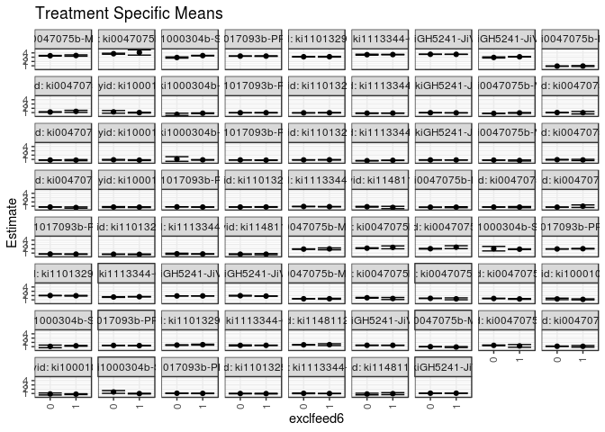

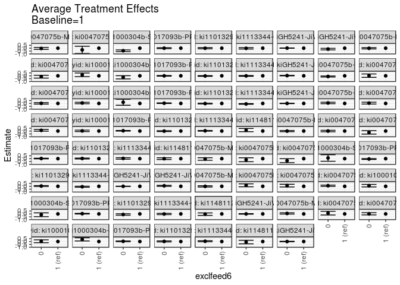

[figure not shown]

## Results Table

### Parameter: TSM

| agecat | studyid | country | intervention_level | baseline_level | estimate | ci_lower | ci_upper |
| --- | --- | --- | --- | --- | --- | --- | --- |
| 0-3 months | ki0047075b-MAL-ED | BANGLADESH | 1 | NA | 3.3893170 | 3.2408401 | 3.5377938 |
| 0-3 months | ki0047075b-MAL-ED | BANGLADESH | 0 | NA | 3.3416150 | 3.2666098 | 3.4166201 |
| 0-3 months | ki0047075b-MAL-ED | BRAZIL | 1 | NA | 4.1001464 | 3.4832446 | 4.7170481 |
| 0-3 months | ki0047075b-MAL-ED | BRAZIL | 0 | NA | 3.8064228 | 3.6939940 | 3.9188516 |
| 0-3 months | ki1000304b-SAS-CompFeed | INDIA | 1 | NA | 3.3695026 | 3.3106339 | 3.4283713 |
| 0-3 months | ki1000304b-SAS-CompFeed | INDIA | 0 | NA | 2.9240440 | 2.7812046 | 3.0668835 |
| 0-3 months | ki1017093b-PROVIDE | BANGLADESH | 1 | NA | 3.2576854 | 3.1913681 | 3.3240028 |
| 0-3 months | ki1017093b-PROVIDE | BANGLADESH | 0 | NA | 3.2579271 | 3.2140165 | 3.3018377 |
| 0-3 months | ki1101329-Keneba | GAMBIA | 1 | NA | 3.1108635 | 3.0275178 | 3.1942091 |
| 0-3 months | ki1101329-Keneba | GAMBIA | 0 | NA | 3.1021736 | 3.0426937 | 3.1616534 |
| 0-3 months | ki1113344-GMS-Nepal | NEPAL | 1 | NA | 3.6086209 | 3.5501702 | 3.6670716 |
| 0-3 months | ki1113344-GMS-Nepal | NEPAL | 0 | NA | 3.5825556 | 3.4745781 | 3.6905331 |
| 0-3 months | kiGH5241-JiVitA-3 | BANGLADESH | 1 | NA | 3.6633078 | 3.6498621 | 3.6767534 |
| 0-3 months | kiGH5241-JiVitA-3 | BANGLADESH | 0 | NA | 3.6766858 | 3.6539793 | 3.6993923 |
| 0-3 months | kiGH5241-JiVitA-4 | BANGLADESH | 1 | NA | 3.0917713 | 3.0384192 | 3.1451234 |
| 0-3 months | kiGH5241-JiVitA-4 | BANGLADESH | 0 | NA | 2.9357176 | 2.8105903 | 3.0608448 |
| 3-6 months | ki0047075b-MAL-ED | BANGLADESH | 1 | NA | 1.9726731 | 1.7580555 | 2.1872908 |
| 3-6 months | ki0047075b-MAL-ED | BANGLADESH | 0 | NA | 1.9174759 | 1.8644539 | 1.9704979 |
| 3-6 months | ki0047075b-MAL-ED | BRAZIL | 1 | NA | 2.3223975 | 1.9862237 | 2.6585713 |
| 3-6 months | ki0047075b-MAL-ED | BRAZIL | 0 | NA | 2.1344653 | 2.0521326 | 2.2167981 |
| 3-6 months | ki0047075b-MAL-ED | PERU | 1 | NA | 2.3622909 | 2.0228505 | 2.7017313 |
| 3-6 months | ki0047075b-MAL-ED | PERU | 0 | NA | 2.0104898 | 1.9431975 | 2.0777821 |
| 3-6 months | ki1000304b-SAS-CompFeed | INDIA | 1 | NA | 1.8959468 | 1.8172862 | 1.9746075 |
| 3-6 months | ki1000304b-SAS-CompFeed | INDIA | 0 | NA | 2.0175913 | 1.4898496 | 2.5453330 |
| 3-6 months | ki1017093b-PROVIDE | BANGLADESH | 1 | NA | 2.0123653 | 1.9459774 | 2.0787532 |
| 3-6 months | ki1017093b-PROVIDE | BANGLADESH | 0 | NA | 1.9526626 | 1.9133559 | 1.9919692 |
| 3-6 months | ki1101329-Keneba | GAMBIA | 1 | NA | 1.9608199 | 1.8889538 | 2.0326860 |
| 3-6 months | ki1101329-Keneba | GAMBIA | 0 | NA | 2.0045344 | 1.9556831 | 2.0533857 |
| 3-6 months | ki1113344-GMS-Nepal | NEPAL | 1 | NA | 1.7338087 | 1.6881076 | 1.7795099 |
| 3-6 months | ki1113344-GMS-Nepal | NEPAL | 0 | NA | 1.6611934 | 1.5821262 | 1.7402606 |

[output cut: 110 more lines]

### Parameter: E(Y)

| agecat | studyid | country | intervention_level | baseline_level | estimate | ci_lower | ci_upper |
| --- | --- | --- | --- | --- | --- | --- | --- |
| 0-3 months | ki0047075b-MAL-ED | BANGLADESH | NA | NA | 3.3482498 | 3.2804281 | 3.4160715 |
| 0-3 months | ki0047075b-MAL-ED | BRAZIL | NA | NA | 3.8190367 | 3.7078440 | 3.9302295 |
| 0-3 months | ki1000304b-SAS-CompFeed | INDIA | NA | NA | 3.3522434 | 3.2847848 | 3.4197021 |
| 0-3 months | ki1017093b-PROVIDE | BANGLADESH | NA | NA | 3.2576810 | 3.2206777 | 3.2946843 |
| 0-3 months | ki1101329-Keneba | GAMBIA | NA | NA | 3.1044617 | 3.0557519 | 3.1531714 |
| 0-3 months | ki1113344-GMS-Nepal | NEPAL | NA | NA | 3.5982617 | 3.5465367 | 3.6499867 |
| 0-3 months | kiGH5241-JiVitA-3 | BANGLADESH | NA | NA | 3.6664276 | 3.6538579 | 3.6789973 |
| 0-3 months | kiGH5241-JiVitA-4 | BANGLADESH | NA | NA | 3.0659983 | 3.0164756 | 3.1155211 |
| 3-6 months | ki0047075b-MAL-ED | BANGLADESH | NA | NA | 1.9247979 | 1.8735932 | 1.9760025 |
| 3-6 months | ki0047075b-MAL-ED | BRAZIL | NA | NA | 2.1460815 | 2.0668679 | 2.2252951 |
| 3-6 months | ki0047075b-MAL-ED | PERU | NA | NA | 2.0171026 | 1.9506965 | 2.0835088 |
| 3-6 months | ki1000304b-SAS-CompFeed | INDIA | NA | NA | 1.9051097 | 1.8384221 | 1.9717974 |
| 3-6 months | ki1017093b-PROVIDE | BANGLADESH | NA | NA | 1.9657457 | 1.9318660 | 1.9996254 |
| 3-6 months | ki1101329-Keneba | GAMBIA | NA | NA | 1.9931730 | 1.9526530 | 2.0336930 |
| 3-6 months | ki1113344-GMS-Nepal | NEPAL | NA | NA | 1.7086613 | 1.6690533 | 1.7482692 |
| 3-6 months | kiGH5241-JiVitA-3 | BANGLADESH | NA | NA | 1.9190532 | 1.9057476 | 1.9323587 |
| 3-6 months | kiGH5241-JiVitA-4 | BANGLADESH | NA | NA | 1.8947099 | 1.8645495 | 1.9248703 |
| 6-9 months | ki0047075b-MAL-ED | BANGLADESH | NA | NA | 1.2541293 | 1.2135456 | 1.2947130 |
| 6-9 months | ki0047075b-MAL-ED | BRAZIL | NA | NA | 1.4831159 | 1.4026580 | 1.5635738 |
| 6-9 months | ki0047075b-MAL-ED | NEPAL | NA | NA | 1.3520991 | 1.3076136 | 1.3965845 |
| 6-9 months | ki0047075b-MAL-ED | PERU | NA | NA | 1.3199965 | 1.2656612 | 1.3743319 |
| 6-9 months | ki1000109-EE | PAKISTAN | NA | NA | 1.1260884 | 1.0085133 | 1.2436636 |
| 6-9 months | ki1000304b-SAS-CompFeed | INDIA | NA | NA | 1.2100652 | 1.1296030 | 1.2905275 |
| 6-9 months | ki1017093b-PROVIDE | BANGLADESH | NA | NA | 1.2824185 | 1.2571827 | 1.3076542 |
| 6-9 months | ki1101329-Keneba | GAMBIA | NA | NA | 1.4042923 | 1.3508641 | 1.4577205 |
| 6-9 months | ki1113344-GMS-Nepal | NEPAL | NA | NA | 1.3140299 | 1.2729534 | 1.3551064 |
| 6-9 months | ki1148112-LCNI-5 | MALAWI | NA | NA | 1.4372604 | 1.3755150 | 1.4990057 |
| 6-9 months | kiGH5241-JiVitA-4 | BANGLADESH | NA | NA | 1.3251314 | 1.3038170 | 1.3464459 |
| 9-12 months | ki0047075b-MAL-ED | BANGLADESH | NA | NA | 0.9848124 | 0.9457805 | 1.0238444 |
| 9-12 months | ki0047075b-MAL-ED | BRAZIL | NA | NA | 1.2982559 | 1.2240694 | 1.3724425 |
| 9-12 months | ki0047075b-MAL-ED | PERU | NA | NA | 1.0985124 | 1.0475959 | 1.1494289 |
| 9-12 months | ki1000109-EE | PAKISTAN | NA | NA | 0.8484117 | 0.7632855 | 0.9335379 |
| 9-12 months | ki1000304b-SAS-CompFeed | INDIA | NA | NA | 0.9826276 | 0.9088962 | 1.0563590 |
| 9-12 months | ki1017093b-PROVIDE | BANGLADESH | NA | NA | 1.0499750 | 1.0230130 | 1.0769370 |
| 9-12 months | ki1101329-Keneba | GAMBIA | NA | NA | 0.9818764 | 0.9392834 | 1.0244694 |
| 9-12 months | ki1113344-GMS-Nepal | NEPAL | NA | NA | 0.9981924 | 0.9647527 | 1.0316321 |
| 9-12 months | ki1148112-LCNI-5 | MALAWI | NA | NA | 0.9706344 | 0.8246089 | 1.1166600 |
| 9-12 months | kiGH5241-JiVitA-4 | BANGLADESH | NA | NA | 1.0696646 | 1.0503114 | 1.0890177 |
| 12-15 months | ki0047075b-MAL-ED | BANGLADESH | NA | NA | 0.9199912 | 0.8786810 | 0.9613015 |
| 12-15 months | ki0047075b-MAL-ED | BRAZIL | NA | NA | 1.1421774 | 1.0831447 | 1.2012100 |
| 12-15 months | ki1000109-EE | PAKISTAN | NA | NA | 1.0223758 | 0.9334119 | 1.1113396 |
| 12-15 months | ki1000304b-SAS-CompFeed | INDIA | NA | NA | 0.8406400 | 0.7684485 | 0.9128315 |
| 12-15 months | ki1017093b-PROVIDE | BANGLADESH | NA | NA | 0.9597501 | 0.9335899 | 0.9859102 |
| 12-15 months | ki1101329-Keneba | GAMBIA | NA | NA | 0.9424871 | 0.9117122 | 0.9732620 |
| 12-15 months | ki1113344-GMS-Nepal | NEPAL | NA | NA | 0.8704063 | 0.8447703 | 0.8960424 |
| 12-15 months | kiGH5241-JiVitA-4 | BANGLADESH | NA | NA | 0.9393119 | 0.9219119 | 0.9567119 |
| 15-18 months | ki0047075b-MAL-ED | BANGLADESH | NA | NA | 0.8230330 | 0.7852223 | 0.8608436 |
| 15-18 months | ki0047075b-MAL-ED | BRAZIL | NA | NA | 1.0021114 | 0.9429996 | 1.0612232 |
| 15-18 months | ki0047075b-MAL-ED | NEPAL | NA | NA | 0.8425951 | 0.7997829 | 0.8854074 |
| 15-18 months | ki1000109-EE | PAKISTAN | NA | NA | 0.8381757 | 0.7627800 | 0.9135715 |
| 15-18 months | ki1000304b-SAS-CompFeed | INDIA | NA | NA | 0.8909184 | 0.8304593 | 0.9513775 |
| 15-18 months | ki1017093b-PROVIDE | BANGLADESH | NA | NA | 0.8560998 | 0.8320145 | 0.8801852 |
| 15-18 months | ki1101329-Keneba | GAMBIA | NA | NA | 0.8848169 | 0.8522726 | 0.9173611 |
| 15-18 months | ki1113344-GMS-Nepal | NEPAL | NA | NA | 0.7603933 | 0.7281594 | 0.7926271 |
| 15-18 months | kiGH5241-JiVitA-4 | BANGLADESH | NA | NA | 0.8612746 | 0.8433730 | 0.8791761 |
| 18-21 months | ki0047075b-MAL-ED | BANGLADESH | NA | NA | 0.8195860 | 0.7845702 | 0.8546019 |
| 18-21 months | ki0047075b-MAL-ED | BRAZIL | NA | NA | 0.9160758 | 0.8452655 | 0.9868862 |
| 18-21 months | ki0047075b-MAL-ED | NEPAL | NA | NA | 0.8108531 | 0.7724296 | 0.8492765 |
| 18-21 months | ki1000109-EE | PAKISTAN | NA | NA | 0.7870620 | 0.7131718 | 0.8609522 |
| 18-21 months | ki1017093b-PROVIDE | BANGLADESH | NA | NA | 0.8393377 | 0.8153485 | 0.8633269 |
| 18-21 months | ki1101329-Keneba | GAMBIA | NA | NA | 0.8142039 | 0.7785744 | 0.8498334 |
| 18-21 months | ki1113344-GMS-Nepal | NEPAL | NA | NA | 0.9058703 | 0.8708102 | 0.9409303 |
| 18-21 months | ki1148112-LCNI-5 | MALAWI | NA | NA | 0.8419773 | 0.7481346 | 0.9358201 |
| 21-24 months | ki0047075b-MAL-ED | BANGLADESH | NA | NA | 0.7717324 | 0.7354003 | 0.8080644 |
| 21-24 months | ki0047075b-MAL-ED | BRAZIL | NA | NA | 0.7961519 | 0.7521041 | 0.8401997 |
| 21-24 months | ki0047075b-MAL-ED | NEPAL | NA | NA | 0.7862274 | 0.7444562 | 0.8279985 |
| 21-24 months | ki1017093b-PROVIDE | BANGLADESH | NA | NA | 0.7631391 | 0.7377453 | 0.7885328 |
| 21-24 months | ki1101329-Keneba | GAMBIA | NA | NA | 0.7172946 | 0.6823819 | 0.7522072 |
| 21-24 months | ki1113344-GMS-Nepal | NEPAL | NA | NA | 0.7949572 | 0.7486969 | 0.8412176 |
| 21-24 months | ki1148112-LCNI-5 | MALAWI | NA | NA | 0.7342569 | 0.6662316 | 0.8022822 |

### Parameter: ATE

| agecat | studyid | country | intervention_level | baseline_level | estimate | ci_lower | ci_upper |
| --- | --- | --- | --- | --- | --- | --- | --- |
| 0-3 months | ki0047075b-MAL-ED | BANGLADESH | 1 | 1 | 0.0000000 | 0.0000000 | 0.0000000 |
| 0-3 months | ki0047075b-MAL-ED | BANGLADESH | 0 | 1 | -0.0477020 | -0.2140326 | 0.1186287 |
| 0-3 months | ki0047075b-MAL-ED | BRAZIL | 1 | 1 | 0.0000000 | 0.0000000 | 0.0000000 |
| 0-3 months | ki0047075b-MAL-ED | BRAZIL | 0 | 1 | -0.2937235 | -0.9207865 | 0.3333394 |
| 0-3 months | ki1000304b-SAS-CompFeed | INDIA | 1 | 1 | 0.0000000 | 0.0000000 | 0.0000000 |
| 0-3 months | ki1000304b-SAS-CompFeed | INDIA | 0 | 1 | -0.4454586 | -0.5939152 | -0.2970019 |
| 0-3 months | ki1017093b-PROVIDE | BANGLADESH | 1 | 1 | 0.0000000 | 0.0000000 | 0.0000000 |
| 0-3 months | ki1017093b-PROVIDE | BANGLADESH | 0 | 1 | 0.0002417 | -0.0788924 | 0.0793757 |
| 0-3 months | ki1101329-Keneba | GAMBIA | 1 | 1 | 0.0000000 | 0.0000000 | 0.0000000 |
| 0-3 months | ki1101329-Keneba | GAMBIA | 0 | 1 | -0.0086899 | -0.1102873 | 0.0929075 |
| 0-3 months | ki1113344-GMS-Nepal | NEPAL | 1 | 1 | 0.0000000 | 0.0000000 | 0.0000000 |
| 0-3 months | ki1113344-GMS-Nepal | NEPAL | 0 | 1 | -0.0260653 | -0.1484793 | 0.0963487 |
| 0-3 months | kiGH5241-JiVitA-3 | BANGLADESH | 1 | 1 | 0.0000000 | 0.0000000 | 0.0000000 |
| 0-3 months | kiGH5241-JiVitA-3 | BANGLADESH | 0 | 1 | 0.0133780 | -0.0103495 | 0.0371055 |
| 0-3 months | kiGH5241-JiVitA-4 | BANGLADESH | 1 | 1 | 0.0000000 | 0.0000000 | 0.0000000 |
| 0-3 months | kiGH5241-JiVitA-4 | BANGLADESH | 0 | 1 | -0.1560537 | -0.2907756 | -0.0213318 |
| 3-6 months | ki0047075b-MAL-ED | BANGLADESH | 1 | 1 | 0.0000000 | 0.0000000 | 0.0000000 |
| 3-6 months | ki0047075b-MAL-ED | BANGLADESH | 0 | 1 | -0.0551972 | -0.2770174 | 0.1666230 |
| 3-6 months | ki0047075b-MAL-ED | BRAZIL | 1 | 1 | 0.0000000 | 0.0000000 | 0.0000000 |
| 3-6 months | ki0047075b-MAL-ED | BRAZIL | 0 | 1 | -0.1879322 | -0.5326017 | 0.1567374 |
| 3-6 months | ki0047075b-MAL-ED | PERU | 1 | 1 | 0.0000000 | 0.0000000 | 0.0000000 |
| 3-6 months | ki0047075b-MAL-ED | PERU | 0 | 1 | -0.3518011 | -0.6978474 | -0.0057548 |
| 3-6 months | ki1000304b-SAS-CompFeed | INDIA | 1 | 1 | 0.0000000 | 0.0000000 | 0.0000000 |
| 3-6 months | ki1000304b-SAS-CompFeed | INDIA | 0 | 1 | 0.1216445 | -0.4499236 | 0.6932125 |
| 3-6 months | ki1017093b-PROVIDE | BANGLADESH | 1 | 1 | 0.0000000 | 0.0000000 | 0.0000000 |
| 3-6 months | ki1017093b-PROVIDE | BANGLADESH | 0 | 1 | -0.0597027 | -0.1369142 | 0.0175088 |
| 3-6 months | ki1101329-Keneba | GAMBIA | 1 | 1 | 0.0000000 | 0.0000000 | 0.0000000 |
| 3-6 months | ki1101329-Keneba | GAMBIA | 0 | 1 | 0.0437145 | -0.0431445 | 0.1305735 |
| 3-6 months | ki1113344-GMS-Nepal | NEPAL | 1 | 1 | 0.0000000 | 0.0000000 | 0.0000000 |
| 3-6 months | ki1113344-GMS-Nepal | NEPAL | 0 | 1 | -0.0726153 | -0.1640247 | 0.0187940 |

[output cut: 110 more lines]

### Parameter: PAR

| agecat | studyid | country | intervention_level | baseline_level | estimate | ci_lower | ci_upper |
| --- | --- | --- | --- | --- | --- | --- | --- |
| 0-3 months | ki0047075b-MAL-ED | BANGLADESH | 1 | NA | -0.0410672 | -0.1838776 | 0.1017432 |
| 0-3 months | ki0047075b-MAL-ED | BRAZIL | 1 | NA | -0.2811096 | -0.8813136 | 0.3190943 |
| 0-3 months | ki1000304b-SAS-CompFeed | INDIA | 1 | NA | -0.0172592 | -0.0279700 | -0.0065484 |
| 0-3 months | ki1017093b-PROVIDE | BANGLADESH | 1 | NA | -0.0000044 | -0.0595418 | 0.0595330 |
| 0-3 months | ki1101329-Keneba | GAMBIA | 1 | NA | -0.0064018 | -0.0753848 | 0.0625812 |
| 0-3 months | ki1113344-GMS-Nepal | NEPAL | 1 | NA | -0.0103591 | -0.0428950 | 0.0221767 |
| 0-3 months | kiGH5241-JiVitA-3 | BANGLADESH | 1 | NA | 0.0031198 | -0.0022689 | 0.0085086 |
| 0-3 months | kiGH5241-JiVitA-4 | BANGLADESH | 1 | NA | -0.0257729 | -0.0469573 | -0.0045886 |
| 3-6 months | ki0047075b-MAL-ED | BANGLADESH | 1 | NA | -0.0478753 | -0.2447001 | 0.1489495 |
| 3-6 months | ki0047075b-MAL-ED | BRAZIL | 1 | NA | -0.1763160 | -0.5044021 | 0.1517702 |
| 3-6 months | ki0047075b-MAL-ED | PERU | 1 | NA | -0.3451883 | -0.6826324 | -0.0077441 |
| 3-6 months | ki1000304b-SAS-CompFeed | INDIA | 1 | NA | 0.0091629 | -0.0111747 | 0.0295005 |
| 3-6 months | ki1017093b-PROVIDE | BANGLADESH | 1 | NA | -0.0466196 | -0.1059314 | 0.0126923 |
| 3-6 months | ki1101329-Keneba | GAMBIA | 1 | NA | 0.0323531 | -0.0300080 | 0.0947143 |
| 3-6 months | ki1113344-GMS-Nepal | NEPAL | 1 | NA | -0.0251474 | -0.0502816 | -0.0000132 |
| 3-6 months | kiGH5241-JiVitA-3 | BANGLADESH | 1 | NA | -0.0002411 | -0.0067590 | 0.0062768 |
| 3-6 months | kiGH5241-JiVitA-4 | BANGLADESH | 1 | NA | 0.0123436 | -0.0006235 | 0.0253106 |
| 6-9 months | ki0047075b-MAL-ED | BANGLADESH | 1 | NA | -0.0102468 | -0.1086218 | 0.0881282 |
| 6-9 months | ki0047075b-MAL-ED | BRAZIL | 1 | NA | 0.1675127 | -0.0747160 | 0.4097414 |
| 6-9 months | ki0047075b-MAL-ED | NEPAL | 1 | NA | 0.1124208 | -0.1141478 | 0.3389893 |
| 6-9 months | ki0047075b-MAL-ED | PERU | 1 | NA | 0.1001601 | -0.0066119 | 0.2069321 |
| 6-9 months | ki1000109-EE | PAKISTAN | 1 | NA | 0.0116647 | -0.0144891 | 0.0378184 |
| 6-9 months | ki1000304b-SAS-CompFeed | INDIA | 1 | NA | -0.0008870 | -0.0169575 | 0.0151834 |
| 6-9 months | ki1017093b-PROVIDE | BANGLADESH | 1 | NA | 0.0290268 | -0.0177154 | 0.0757689 |
| 6-9 months | ki1101329-Keneba | GAMBIA | 1 | NA | -0.0651596 | -0.1583931 | 0.0280739 |
| 6-9 months | ki1113344-GMS-Nepal | NEPAL | 1 | NA | -0.0004209 | -0.0284815 | 0.0276398 |
| 6-9 months | ki1148112-LCNI-5 | MALAWI | 1 | NA | -0.0359911 | -0.2206058 | 0.1486235 |
| 6-9 months | kiGH5241-JiVitA-4 | BANGLADESH | 1 | NA | 0.0007718 | -0.0097024 | 0.0112460 |
| 9-12 months | ki0047075b-MAL-ED | BANGLADESH | 1 | NA | 0.0678176 | -0.0280748 | 0.1637100 |
| 9-12 months | ki0047075b-MAL-ED | BRAZIL | 1 | NA | 0.1191430 | -0.1896970 | 0.4279831 |
| 9-12 months | ki0047075b-MAL-ED | PERU | 1 | NA | 0.0118094 | -0.1737109 | 0.1973297 |
| 9-12 months | ki1000109-EE | PAKISTAN | 1 | NA | 0.0049059 | -0.0238483 | 0.0336600 |
| 9-12 months | ki1000304b-SAS-CompFeed | INDIA | 1 | NA | 0.0063687 | -0.0031400 | 0.0158774 |
| 9-12 months | ki1017093b-PROVIDE | BANGLADESH | 1 | NA | 0.0249084 | -0.0240065 | 0.0738233 |
| 9-12 months | ki1101329-Keneba | GAMBIA | 1 | NA | 0.0119021 | -0.0513317 | 0.0751360 |
| 9-12 months | ki1113344-GMS-Nepal | NEPAL | 1 | NA | 0.0066486 | -0.0159333 | 0.0292305 |
| 9-12 months | ki1148112-LCNI-5 | MALAWI | 1 | NA | 0.0109293 | -0.2126639 | 0.2345226 |
| 9-12 months | kiGH5241-JiVitA-4 | BANGLADESH | 1 | NA | 0.0003541 | -0.0095644 | 0.0102726 |
| 12-15 months | ki0047075b-MAL-ED | BANGLADESH | 1 | NA | -0.0170729 | -0.1146358 | 0.0804900 |
| 12-15 months | ki0047075b-MAL-ED | BRAZIL | 1 | NA | -0.1404002 | -0.3723425 | 0.0915422 |
| 12-15 months | ki1000109-EE | PAKISTAN | 1 | NA | 0.0229376 | -0.0239780 | 0.0698531 |
| 12-15 months | ki1000304b-SAS-CompFeed | INDIA | 1 | NA | -0.0069089 | -0.0163630 | 0.0025452 |
| 12-15 months | ki1017093b-PROVIDE | BANGLADESH | 1 | NA | -0.0049516 | -0.0471473 | 0.0372442 |
| 12-15 months | ki1101329-Keneba | GAMBIA | 1 | NA | -0.0190420 | -0.0604898 | 0.0224057 |
| 12-15 months | ki1113344-GMS-Nepal | NEPAL | 1 | NA | -0.0040208 | -0.0198312 | 0.0117897 |
| 12-15 months | kiGH5241-JiVitA-4 | BANGLADESH | 1 | NA | 0.0084010 | -0.0013430 | 0.0181450 |
| 15-18 months | ki0047075b-MAL-ED | BANGLADESH | 1 | NA | -0.1037918 | -0.1838296 | -0.0237540 |
| 15-18 months | ki0047075b-MAL-ED | BRAZIL | 1 | NA | 0.0284291 | -0.2489416 | 0.3057997 |
| 15-18 months | ki0047075b-MAL-ED | NEPAL | 1 | NA | 0.0149944 | -0.1145146 | 0.1445034 |
| 15-18 months | ki1000109-EE | PAKISTAN | 1 | NA | 0.0116807 | -0.0096621 | 0.0330235 |
| 15-18 months | ki1000304b-SAS-CompFeed | INDIA | 1 | NA | 0.0042105 | -0.0123389 | 0.0207598 |
| 15-18 months | ki1017093b-PROVIDE | BANGLADESH | 1 | NA | 0.0293404 | -0.0156676 | 0.0743483 |
| 15-18 months | ki1101329-Keneba | GAMBIA | 1 | NA | -0.0143094 | -0.0630919 | 0.0344731 |
| 15-18 months | ki1113344-GMS-Nepal | NEPAL | 1 | NA | -0.0205927 | -0.0361135 | -0.0050719 |
| 15-18 months | kiGH5241-JiVitA-4 | BANGLADESH | 1 | NA | 0.0018236 | -0.0068937 | 0.0105408 |
| 18-21 months | ki0047075b-MAL-ED | BANGLADESH | 1 | NA | 0.0719423 | -0.0379325 | 0.1818170 |
| 18-21 months | ki0047075b-MAL-ED | BRAZIL | 1 | NA | 0.0432739 | -0.1098901 | 0.1964379 |
| 18-21 months | ki0047075b-MAL-ED | NEPAL | 1 | NA | 0.1164784 | -0.0275197 | 0.2604765 |
| 18-21 months | ki1000109-EE | PAKISTAN | 1 | NA | 0.0041563 | -0.0160395 | 0.0243522 |
| 18-21 months | ki1017093b-PROVIDE | BANGLADESH | 1 | NA | 0.0337650 | -0.0096922 | 0.0772222 |
| 18-21 months | ki1101329-Keneba | GAMBIA | 1 | NA | -0.0080183 | -0.0612455 | 0.0452089 |
| 18-21 months | ki1113344-GMS-Nepal | NEPAL | 1 | NA | 0.0089578 | -0.0063409 | 0.0242565 |
| 18-21 months | ki1148112-LCNI-5 | MALAWI | 1 | NA | 0.1311158 | -0.0878515 | 0.3500832 |
| 21-24 months | ki0047075b-MAL-ED | BANGLADESH | 1 | NA | -0.0065640 | -0.1006805 | 0.0875525 |
| 21-24 months | ki0047075b-MAL-ED | BRAZIL | 1 | NA | -0.0040722 | -0.1282938 | 0.1201494 |
| 21-24 months | ki0047075b-MAL-ED | NEPAL | 1 | NA | -0.2240882 | -0.5137054 | 0.0655290 |
| 21-24 months | ki1017093b-PROVIDE | BANGLADESH | 1 | NA | 0.0156598 | -0.0292855 | 0.0606051 |
| 21-24 months | ki1101329-Keneba | GAMBIA | 1 | NA | 0.0196513 | -0.0355194 | 0.0748220 |
| 21-24 months | ki1113344-GMS-Nepal | NEPAL | 1 | NA | 0.0094999 | -0.0205528 | 0.0395527 |
| 21-24 months | ki1148112-LCNI-5 | MALAWI | 1 | NA | -0.0019027 | -0.1321681 | 0.1283628 |